# Data Analysis with R - Final Project

by Samit Chaudhuri

## Chemical Analysis of Red and White Wines

This project explores relationship between quality and chemical properties of wines. Wine quality is based on subjective ratings by human experts. Chemical properties are determined by objective measurements. Two tidy data sets of 1599 red wines and 4898 white wines, each with 11 input variables and 1 output variables are used.

Additionally some models are presented to predict the quality of wines from their chemical characteristics.

### Load data and necessary packages

```r
redWines <- read.csv("wineQualityReds.csv")
redWines <- subset(redWines, select = -c(X))
str(redWines)
```

```
## 'data.frame':    1599 obs. of  12 variables:
##  $ fixed.acidity       : num  7.4 7.8 7.8 11.2 7.4 7.4 7.9 7.3 7.8 7.5 ...
##  $ volatile.acidity    : num  0.7 0.88 0.76 0.28 0.7 0.66 0.6 0.65 0.58 0.5 ...
##  $ citric.acid         : num  0 0 0.04 0.56 0 0 0.06 0 0.02 0.36 ...
##  $ residual.sugar      : num  1.9 2.6 2.3 1.9 1.9 1.8 1.6 1.2 2 6.1 ...
##  $ chlorides           : num  0.076 0.098 0.092 0.075 0.076 0.075 0.069 0.065 0.073 0.071 ...
##  $ free.sulfur.dioxide : num  11 25 15 17 11 13 15 15 9 17 ...
##  $ total.sulfur.dioxide: num  34 67 54 60 34 40 59 21 18 102 ...
##  $ density             : num  0.998 0.997 0.997 0.998 0.998 ...
##  $ pH                  : num  3.51 3.2 3.26 3.16 3.51 3.51 3.3 3.39 3.36 3.35 ...
##  $ sulphates           : num  0.56 0.68 0.65 0.58 0.56 0.56 0.46 0.47 0.57 0.8 ...
##  $ alcohol             : num  9.4 9.8 9.8 9.8 9.4 9.4 9.4 10 9.5 10.5 ...
##  $ quality             : int  5 5 5 6 5 5 5 7 7 5 ...
```

```r
library(ggplot2)
library(GGally)
library(scales)
library(memisc)
library(gridExtra)
qualityLevel = function(quality) {
  level = as.numeric(cut(quality, breaks=c(0, 4, 5, 6, 10)))
  level
  return(level)
}
rpalette = 5
wpalette = 1
ptfont = 10           # font size of plot title
atfont = 9            # font size of axis title
ltfont = 8            # font size of legend title
```

The red wine data has one dependent variable, quality, that gives each wine a score between 0 and 10. There are 11 independent variables, some of with may be correlated.

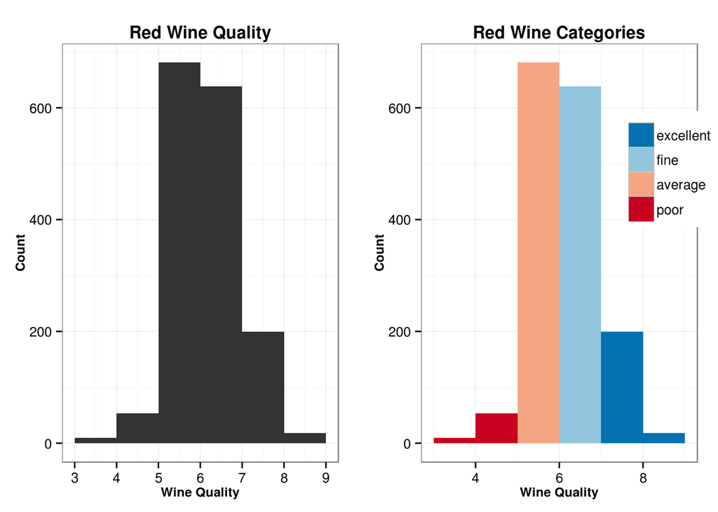

```r
ptfont = 10           # font size of plot title
atfont = 9            # font size of axis title
ltfont = 8            # font size of legend title
rqhist1 <- ggplot(data=redWines, aes(x=quality)) +
    ggtitle("Red Wine Quality") +     # Plot title text
    xlab("Wine Quality") + ylab("Count") +  # Axis label text
    theme_bw() +                                          # Theme elements
    theme(title=element_text(size=ptfont, face="bold"),   # Title font
         axis.title=element_text(size=atfont, face="bold")) +
    scale_x_continuous(limits=c(3,9), breaks = seq(3, 9, 1)) +
    geom_histogram(binwidth = 1)
redWines$quality.label = cut(redWines$quality, breaks=c(0, 4, 5, 6, 10),
    labels=c("poor", "average", "fine", "excellent"))
rqhist2 <- ggplot(data=redWines, aes(x=quality, fill=quality.label)) +
    ggtitle("Red Wine Categories") +     # Plot title text
    xlab("Wine Quality") + ylab("Count") +  # Axis label text
    scale_fill_brewer(type = 'div', palette = rpalette, # Legend title/color
         guide=guide_legend(reverse=TRUE, title="Quality Rating")) +
    theme_bw() +                                          # Theme elements
    theme(title=element_text(size=ptfont, face="bold"),   # Title font
        axis.title=element_text(size=atfont, face="bold"),    # Axis font
        legend.title=element_blank(),
        legend.position=c(.9,.7)) +                       # Legend position
    scale_x_continuous(limits=c(3,9)) +
    geom_histogram(binwidth = 1)
grid.arrange(rqhist1, rqhist2, ncol=2)
```

In the beginning, we don’t really know what causes a wine to be excellent or poor. So we want the entire data set speak for itself by plotting many variables all at once. Hopefully the plots will draw our attention to a smaller set of variables and relationships.

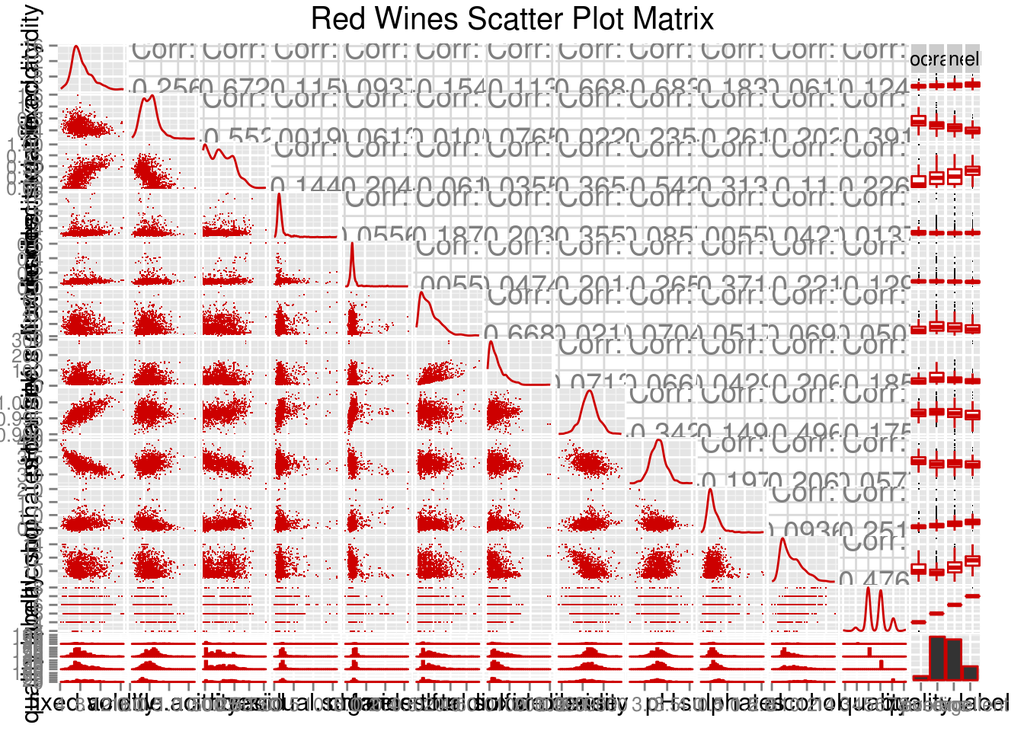

```r
ggpairs(redWines,
        params = c(color=I('red3'), shape = I('.'), corSize=8, outlier.shape = I('.')),
        title = "Red Wines Scatter Plot Matrix")
```

Some of the dependent variables are highly correlated. For example, citric acid is correlated with both fixed and volatile acidity. Density is correlated with both fixed acidity and alcohol content.

We will closely examine the effects of alcohol and acidity (both fixed and volatile) on quality score and quality label with grouped density plots.

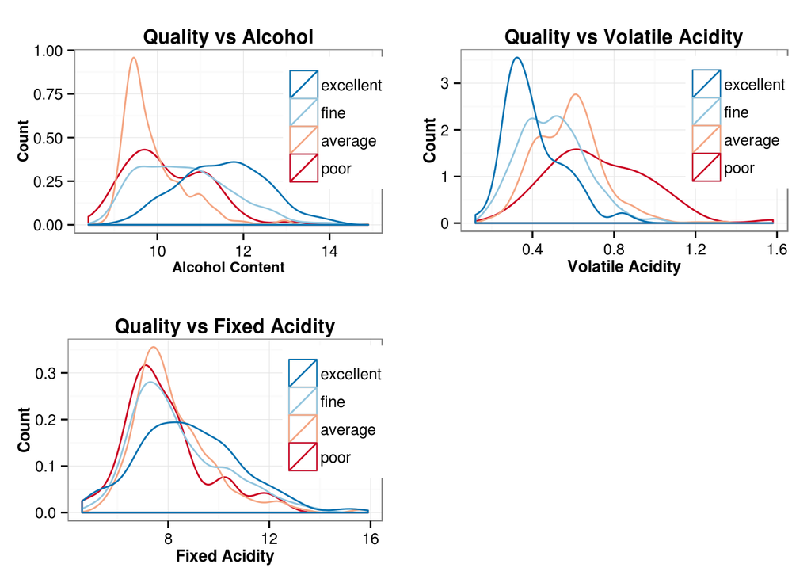

```r
ptfont = 10           # font size of plot title
atfont = 9            # font size of axis title
ltfont = 8            # font size of legend title
alDensity <- ggplot(data=redWines, aes(x=alcohol, color=quality.label)) +
      ggtitle("Quality vs Alcohol") + # Plot title text
      xlab("Alcohol Content") + ylab("Count") +
      scale_color_brewer(type = 'div', palette = rpalette, # Legend title/color
          guide=guide_legend(reverse=TRUE)) +
      theme_bw() +                                          # Theme elements
      theme(title=element_text(size=ptfont, face="bold"),   # Title font
           axis.title=element_text(size=atfont, face="bold"),   # Axis font
           legend.title=element_blank(),
           legend.position=c(.85,.6)) +
      geom_density()
acidDensity <- ggplot(data=redWines) +
      ylab("Count") +
      scale_color_brewer(type = 'div', palette = rpalette, # Legend title/color
          guide=guide_legend(reverse=TRUE)) +
      theme_bw() +                                          # Theme elements
      theme(title=element_text(size=ptfont, face="bold"),   # Title font
           axis.title=element_text(face="bold"),   # Axis font
           legend.title=element_blank(),
           legend.position=c(.85,.6))
vaDensity <- acidDensity +
    geom_density(aes(x=volatile.acidity, color=quality.label)) +
    ggtitle("Quality vs Volatile Acidity") +  # Plot title
    xlab("Volatile Acidity")
faDensity <- acidDensity +
    geom_density(aes(x=fixed.acidity, color = quality.label)) +
    ggtitle("Quality vs Fixed Acidity") +     # Plot title
    xlab("Fixed Acidity")
grid.arrange(alDensity, vaDensity, faDensity, nrow=2, ncol=2)
```

The density plots of different quality levels are shifted with respect to each other. The alcohol density plots shift toward right with improving quality. Better wines tend of have higher alcohol. The fixed acidity plots also shift toward right with improving quality, while volatile acidity density plots shift toward left with improving quality. Better wines tend of have higher fixed acidity and lower volatile acidity.

These trends can also be observed with box plots.

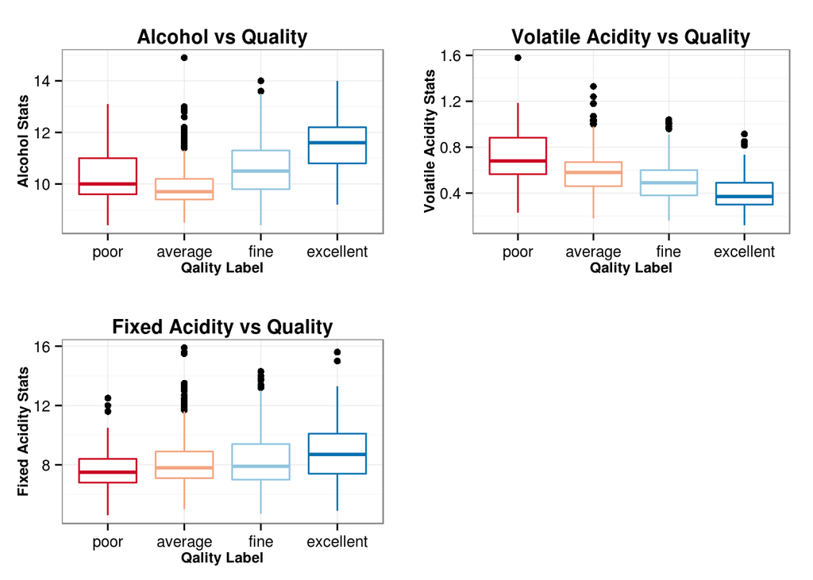

```r
ptfont = 10           # font size of plot title
atfont = 9            # font size of axis title
ltfont = 8            # font size of legend title
albox <- ggplot(data=redWines, aes(x=quality.label, y=alcohol,
       color=quality.label)) +
      ggtitle("Alcohol vs Quality") +     # Plot title text
      xlab("Qality Label") + ylab("Alcohol Stats") +  # Axis label text
      scale_color_brewer(type = 'div', palette = rpalette) +# Legend title/color
      theme_bw() +                                          # Theme elements
      theme(title=element_text(size=ptfont, face="bold"),   # Title font
           axis.title=element_text(size=atfont, face="bold"),   # Axis font
           legend.title=element_text(size=ltfont, face="bold"), # Legend font
           legend.position="none") +                      # Legend position
      geom_boxplot()
abox <- ggplot(data=redWines, aes(x=quality.label, color=quality.label)) +
           # Plot title text
      xlab("Qality Label") +   # Axis label text
      scale_color_brewer(type = 'div', palette = rpalette)+ # Legend color
      theme_bw() +                                          # Theme elements
      theme(title=element_text(size=ptfont, face="bold"),   # Title font
           axis.title=element_text(size=atfont, face="bold"),   # Axis font
           legend.title=element_text(size=ltfont, face="bold"), # Legend font
           legend.position="none")                        # Legend position
par(mfrow=c(1,2))
vabox <- abox + geom_boxplot(aes(y=volatile.acidity)) +
     ggtitle("Volatile Acidity vs Quality") +
     ylab("Volatile Acidity Stats")
fabox <- abox + geom_boxplot(aes(y=fixed.acidity)) +
     ggtitle("Fixed Acidity vs Quality") +
     ylab("Fixed Acidity Stats")
grid.arrange(albox, vabox, fabox, nrow=2, ncol=2)
```

Now let’s observe the joint effect of volatile acidity and alcohol content on quality with a scatter plot. Side-by-side, we also plot the joint effect of fixed acidity and alcohol content.

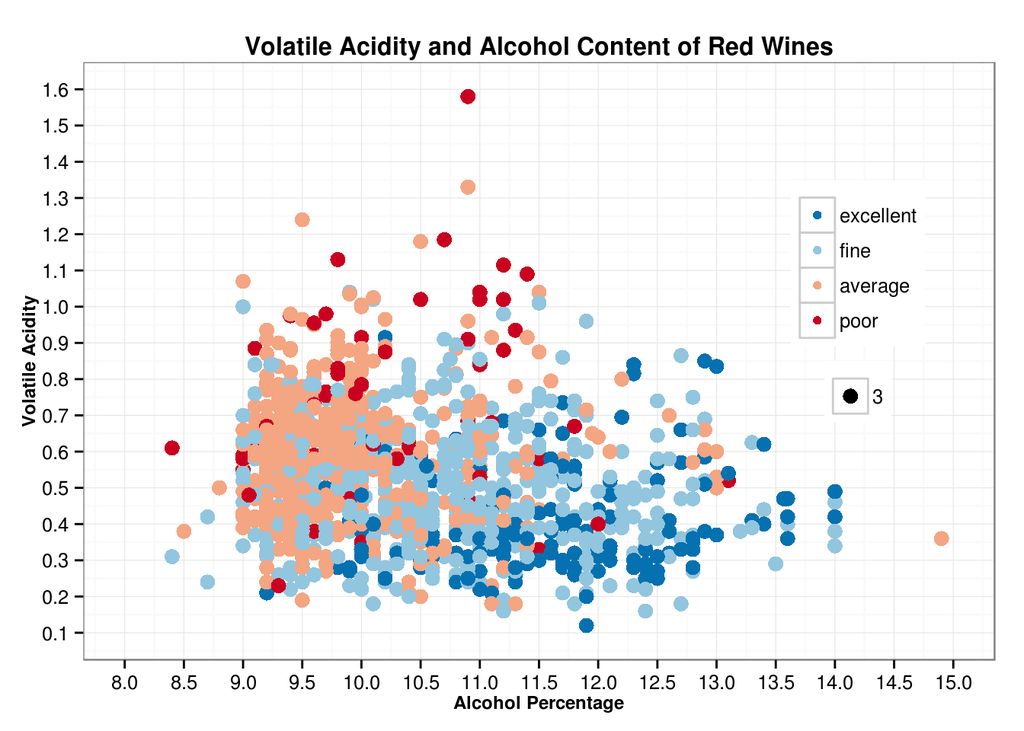

```r
alascatter <- ggplot(data=redWines, aes(x=alcohol,
      group=quality.label, fill=quality.label, color=quality.label)) +
      scale_x_continuous(limits=c(8, 15), breaks = seq(8, 15, .5)) +
      xlab("Alcohol Percentage") + # Axis label text
      scale_color_brewer(type = 'div', palette = rpalette,
          guide=guide_legend(reverse=TRUE)) +              # Legend color
      scale_fill_brewer(guide = FALSE) +
      theme_bw() +                                         # Theme elements
      theme(title=element_text(size=ptfont, face="bold"),  # Title font
           axis.title=element_text(size=atfont, face="bold"),   # Axis font
           legend.title=element_blank(),                   # Legend font
           legend.position=c(.85,.6))                      # Legend position
alvascatter <- alascatter +
      ggtitle("Volatile Acidity and Alcohol Content of Red Wines") +
      ylab("Volatile Acidity") +
      scale_y_continuous(limits=c(0.1, 1.6), breaks = seq(0.1, 1.6, .1)) +
      geom_point(aes(y=volatile.acidity, size=3))
alfascatter <- alascatter +
      ggtitle("Fixed Acidity and Alcohol Content of Red Wines") +
      ylab("Fixed Acidity") +
      scale_y_continuous(limits=c(3, 16), breaks = seq(3, 16, 1)) +
      geom_point(aes(y=fixed.acidity, size=3))
alvascatter
```

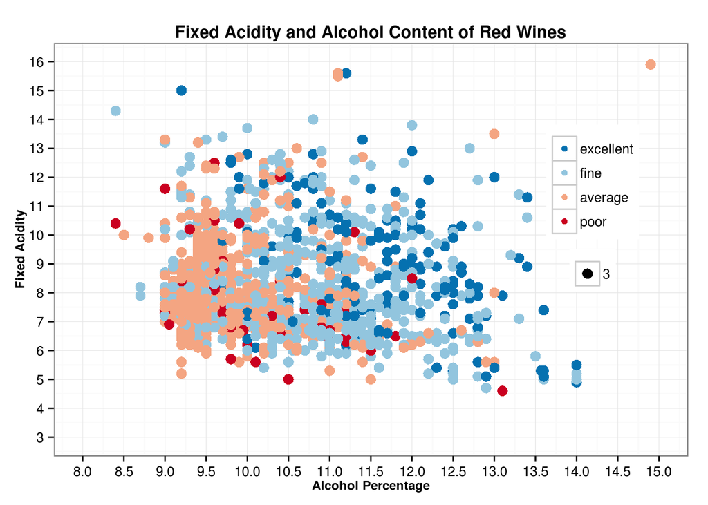

```r
alfascatter
```

### Linear Regression Model of Red Wine Quality

First we start with a full linear regression model.

```r
fulllm <- lm(data=redWines, quality ~ . - quality.label)
summary(fulllm)
```

```
##
## Call:
## lm(formula = quality ~ . - quality.label, data = redWines)
##
## Residuals:
##      Min       1Q   Median       3Q      Max
## -2.68911 -0.36652 -0.04699  0.45202  2.02498
##
## Coefficients:
##                        Estimate Std. Error t value Pr(>|t|)
## (Intercept)           2.197e+01  2.119e+01   1.036   0.3002
## fixed.acidity         2.499e-02  2.595e-02   0.963   0.3357
## volatile.acidity     -1.084e+00  1.211e-01  -8.948  < 2e-16 ***
## citric.acid          -1.826e-01  1.472e-01  -1.240   0.2150
## residual.sugar        1.633e-02  1.500e-02   1.089   0.2765
## chlorides            -1.874e+00  4.193e-01  -4.470 8.37e-06 ***
## free.sulfur.dioxide   4.361e-03  2.171e-03   2.009   0.0447 *
## total.sulfur.dioxide -3.265e-03  7.287e-04  -4.480 8.00e-06 ***
## density              -1.788e+01  2.163e+01  -0.827   0.4086
## pH                   -4.137e-01  1.916e-01  -2.159   0.0310 *
## sulphates             9.163e-01  1.143e-01   8.014 2.13e-15 ***
## alcohol               2.762e-01  2.648e-02  10.429  < 2e-16 ***
## ---
## Signif. codes:  0 '***' 0.001 '**' 0.01 '*' 0.05 '.' 0.1 ' ' 1
##
## Residual standard error: 0.648 on 1587 degrees of freedom
## Multiple R-squared:  0.3606, Adjusted R-squared:  0.3561
## F-statistic: 81.35 on 11 and 1587 DF,  p-value: < 2.2e-16
```

```r
redWines$quality = as.numeric(redWines$quality)
reducedlm <- lm(data=redWines, quality ~ .
    - citric.acid - density - pH - quality.label)
summary(reducedlm)
```

```
##
## Call:
## lm(formula = quality ~ . - citric.acid - density - pH - quality.label,
##     data = redWines)
##
## Residuals:
##     Min      1Q  Median      3Q     Max
## -2.7772 -0.3728 -0.0605  0.4520  2.0213
##
## Coefficients:
##                        Estimate Std. Error t value Pr(>|t|)
## (Intercept)           2.7099270  0.2332016  11.621  < 2e-16 ***
## fixed.acidity         0.0251103  0.0101305   2.479   0.0133 *
## volatile.acidity     -1.0698952  0.1000046 -10.698  < 2e-16 ***
## residual.sugar        0.0072856  0.0120570   0.604   0.5458
## chlorides            -1.7451754  0.3922647  -4.449 9.23e-06 ***
## free.sulfur.dioxide   0.0041719  0.0021259   1.962   0.0499 *
## total.sulfur.dioxide -0.0031126  0.0006882  -4.523 6.56e-06 ***
## sulphates             0.8832980  0.1110258   7.956 3.35e-15 ***
## alcohol               0.2794893  0.0167556  16.680  < 2e-16 ***
## ---
## Signif. codes:  0 '***' 0.001 '**' 0.01 '*' 0.05 '.' 0.1 ' ' 1
##
## Residual standard error: 0.6499 on 1590 degrees of freedom
## Multiple R-squared:  0.3556, Adjusted R-squared:  0.3524
## F-statistic: 109.7 on 8 and 1590 DF,  p-value: < 2.2e-16
```

The R-squared of the reduced model is not much different from the full model. The R-squared did not really improve with models built with other combinations of feature variables.

### Prediction with Classification

One possible reason that linear regression model of red-wine quality has low accuracy is that quality has a non-linear relation with other dependent variables. This prompts us to explore the relationship with a multi-class classification trees. Before building a CART model, we will split the data into a training set and a test set. CART model built on the training set will be used to predict quality on the test set. Then we will be able to measure the accuracy of the predictive capability of the model.

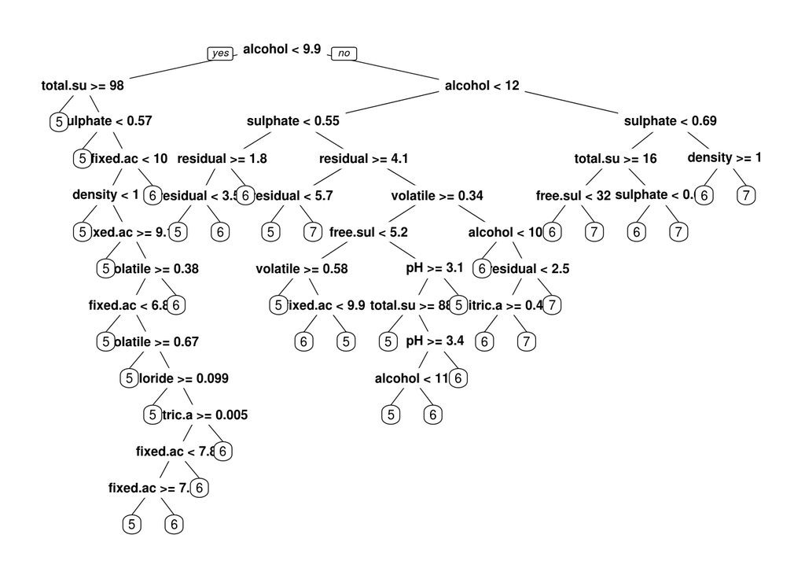

```r
library(rpart)
library(rpart.plot)
library(caret)
library(e1071)

redWines$quality = factor(redWines$quality)

# Split data into a train and test set
index <- 1:nrow(redWines)
set.seed(144)
testSamples <- sample(index, trunc(length(index)/3))
rqindex <- which(colnames(redWines)=="quality")
rqlindex <- which(colnames(redWines)=="quality.label")
redTest <- redWines[testSamples,-rqlindex]
redTrain <- redWines[-testSamples,-rqlindex]

# Create rpart model with cross validation
rtr.control = trainControl(method = "cv", number = 5)
cp.grid = expand.grid( .cp = (0:4)*0.001)
set.seed(144)
rrpart.grid = train(data = redTrain, quality ~ ., method = "rpart",
    trControl = rtr.control, tuneGrid = cp.grid)
rrpart.model = rrpart.grid$finalModel
prp(rrpart.model, tweak=1.5)
```

```r
#Compute confusion matrix
rrpart.cpred <- predict(rrpart.model, newdata=redTest, type = "class" )
rrpart.cmatrix <- table(pred = rrpart.cpred, true = redTest[,rqindex])
rrpart.accuracy <- sum(diag(rrpart.cmatrix))/sum(rrpart.cmatrix)
rrpart.cmatrix
```

```
##     true
## pred   3   4   5   6   7   8
##    3   0   0   0   0   0   0
##    4   0   0   0   0   0   0
##    5   1  15 166  62   4   0
##    6   1   7  61 119  38   2
##    7   0   1  10  21  22   3
##    8   0   0   0   0   0   0
```

```r
rrpart.accuracy
```

```
## [1] 0.575985
```

Indeed, the CART model can predict quality on the test set with 58% accuracy.

### Chemical Analysis of White Wines

We now perform EDA on white wine quality and see if they follow a similar pattern as red wines.

```r
whiteWines <- read.csv("wineQualityWhites.csv")
whiteWines <- subset(whiteWines, select = -c(X))
str(whiteWines)
```

```
## 'data.frame':    4898 obs. of  12 variables:
##  $ fixed.acidity       : num  7 6.3 8.1 7.2 7.2 8.1 6.2 7 6.3 8.1 ...
##  $ volatile.acidity    : num  0.27 0.3 0.28 0.23 0.23 0.28 0.32 0.27 0.3 0.22 ...
##  $ citric.acid         : num  0.36 0.34 0.4 0.32 0.32 0.4 0.16 0.36 0.34 0.43 ...
##  $ residual.sugar      : num  20.7 1.6 6.9 8.5 8.5 6.9 7 20.7 1.6 1.5 ...
##  $ chlorides           : num  0.045 0.049 0.05 0.058 0.058 0.05 0.045 0.045 0.049 0.044 ...
##  $ free.sulfur.dioxide : num  45 14 30 47 47 30 30 45 14 28 ...
##  $ total.sulfur.dioxide: num  170 132 97 186 186 97 136 170 132 129 ...
##  $ density             : num  1.001 0.994 0.995 0.996 0.996 ...
##  $ pH                  : num  3 3.3 3.26 3.19 3.19 3.26 3.18 3 3.3 3.22 ...
##  $ sulphates           : num  0.45 0.49 0.44 0.4 0.4 0.44 0.47 0.45 0.49 0.45 ...
##  $ alcohol             : num  8.8 9.5 10.1 9.9 9.9 10.1 9.6 8.8 9.5 11 ...
##  $ quality             : int  6 6 6 6 6 6 6 6 6 6 ...
```

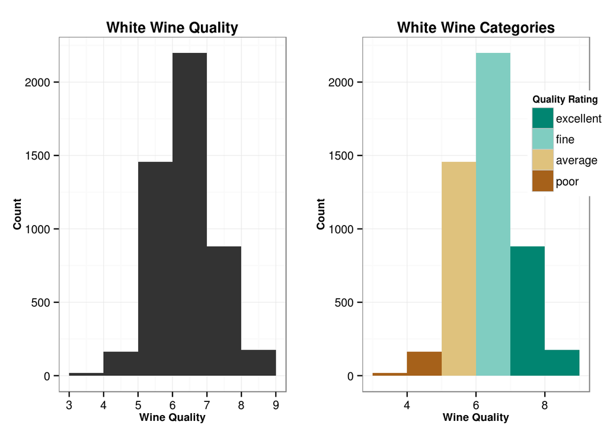

```r
whiteWines$quality.label = cut(whiteWines$quality, breaks=c(0, 4, 5, 6, 10),
    labels=c("poor", "average", "fine", "excellent"))
wqhist1 <- ggplot(data=whiteWines, aes(x=quality)) +
      ggtitle("White Wine Quality") +     # Plot title text
      xlab("Wine Quality") + ylab("Count") +  # Axis label text
      theme_bw() +                                          # Theme elements
      theme(title=element_text(size=ptfont, face="bold"),   # Title font
           axis.title=element_text(size=atfont, face="bold")) +
      scale_x_continuous(limits=c(3,9), breaks = seq(3, 9, 1)) +
      geom_histogram(binwidth = 1)
wqhist2 <- ggplot(data=whiteWines, aes(x=quality, fill=quality.label)) +
          ggtitle("White Wine Categories") +     # Plot title text
          xlab("Wine Quality") + ylab("Count") +  # Axis label text
          scale_fill_brewer(type = 'div', palette = wpalette,
              guide=guide_legend(reverse=TRUE, title="Quality Rating")) +
          theme_bw() +                                          # Theme elements
          theme(title=element_text(size=ptfont, face="bold"),   # Title font
             axis.title=element_text(size=atfont, face="bold"),   # Axis font
             legend.title=element_text(size=ltfont, face="bold"), # Legend font
             legend.position=c(.9,.7)) +                      # Legend position
          scale_x_continuous(limits=c(3,9)) +
          geom_histogram(binwidth = 1)
grid.arrange(wqhist1, wqhist2, ncol=2)
```

Now plot all vriable pairs in the data set to identify noticable relationships.

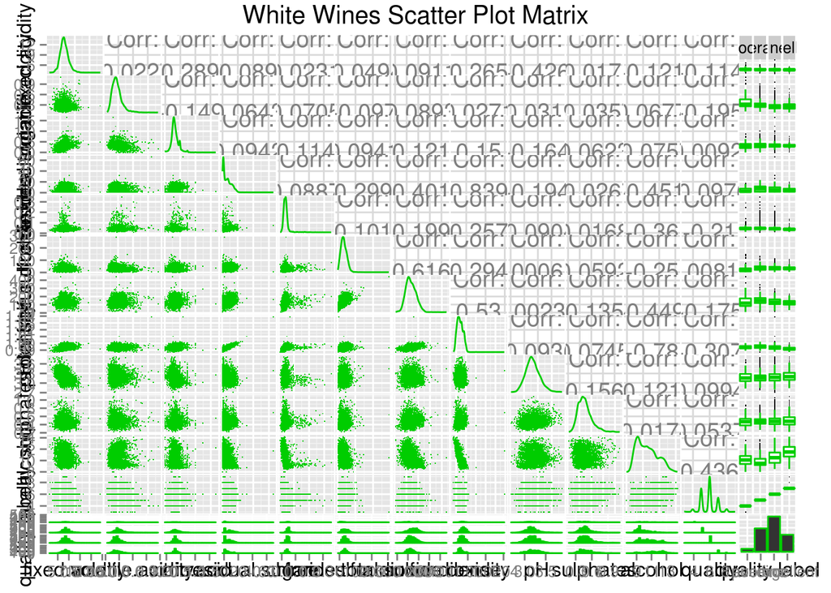

```r
ggpairs(whiteWines,
        params = c(color=I('green3'), shape = I('.'), corSize=8,
            outlier.shape = I('.')),
        title = "White Wines Scatter Plot Matrix")
```

Similar to quality or red wines, quality of white wines also relate to alcohol content and acidity. We can examine these relations with scatterplots.

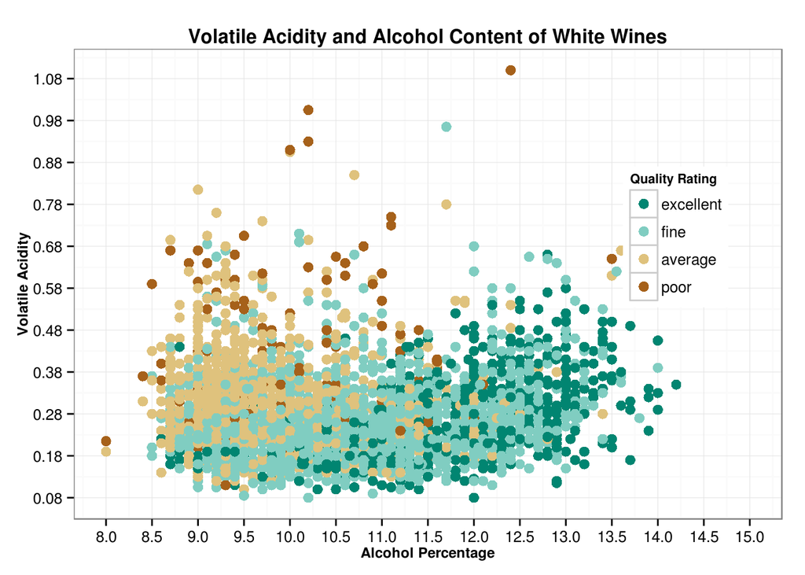

```r
alascatter <- ggplot(data=whiteWines, aes(x=alcohol,
      group=quality.label, fill=quality.label, color=quality.label)) +
      scale_x_continuous(limits=c(8, 15), breaks = seq(8, 15, .5)) +
      xlab("Alcohol Percentage") +  # Axis label text
      scale_color_brewer(type = 'div', palette = wpalette,  # Legend color
          guide=guide_legend(reverse=TRUE, title="Quality Rating")) +
      scale_fill_brewer(guide = FALSE) +
      theme_bw() +                                          # Theme elements
      theme(title=element_text(size=ptfont, face="bold"),   # Title font
           axis.title=element_text(size=atfont, face="bold"),   # Axis font
           legend.title=element_text(size=ltfont, face="bold"), # Legend font
           legend.position=c(.85, .6))                    # Legend position
alvascatter <- alascatter +
      ylab("Volatile Acidity") +
      scale_y_continuous(limits=c(0.08, 1.1), breaks = seq(0.08, 1.1, .1)) +
      ggtitle("Volatile Acidity and Alcohol Content of White Wines") +
      geom_point(aes(y=volatile.acidity), size=3)
alfascatter <- alascatter +
      ylab("Fixed Acidity") +
      scale_y_continuous(limits=c(3, 16), breaks = seq(3, 16, 1)) +
      ggtitle("Fixed Acidity and Alcohol Content of White Wines") +
      geom_point(aes(y=fixed.acidity), size=3)
alvascatter
```

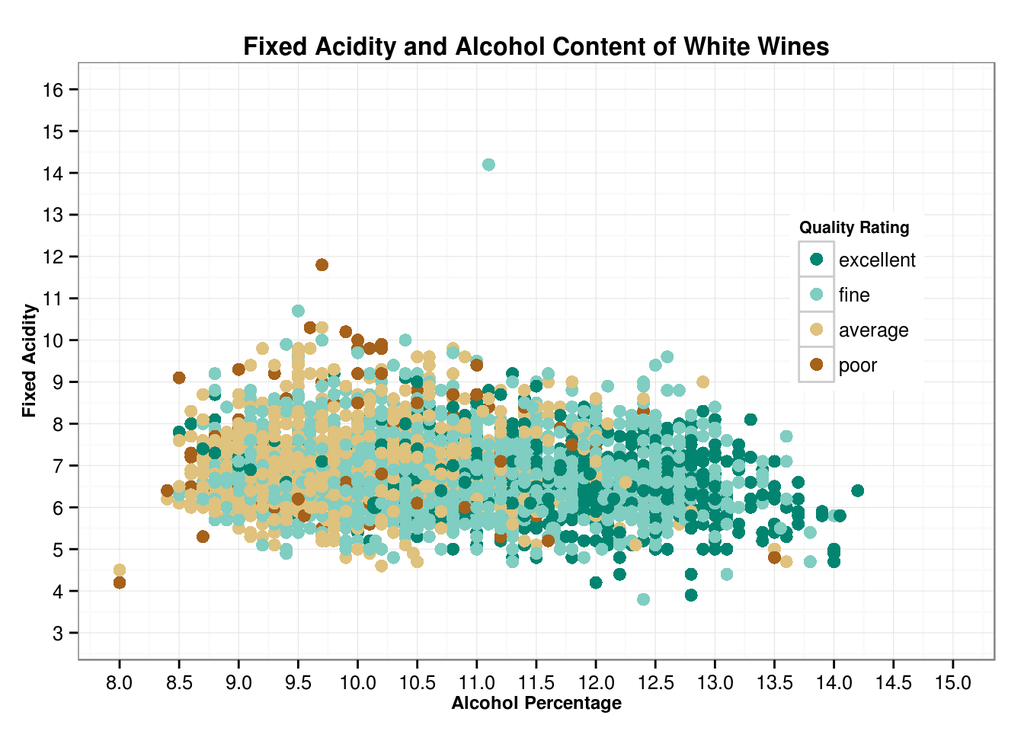

```r
alfascatter
```

We can also create a classification tree for prediction. The model can predict quality on the test set with 52% accuracy. The CART is drawn below.

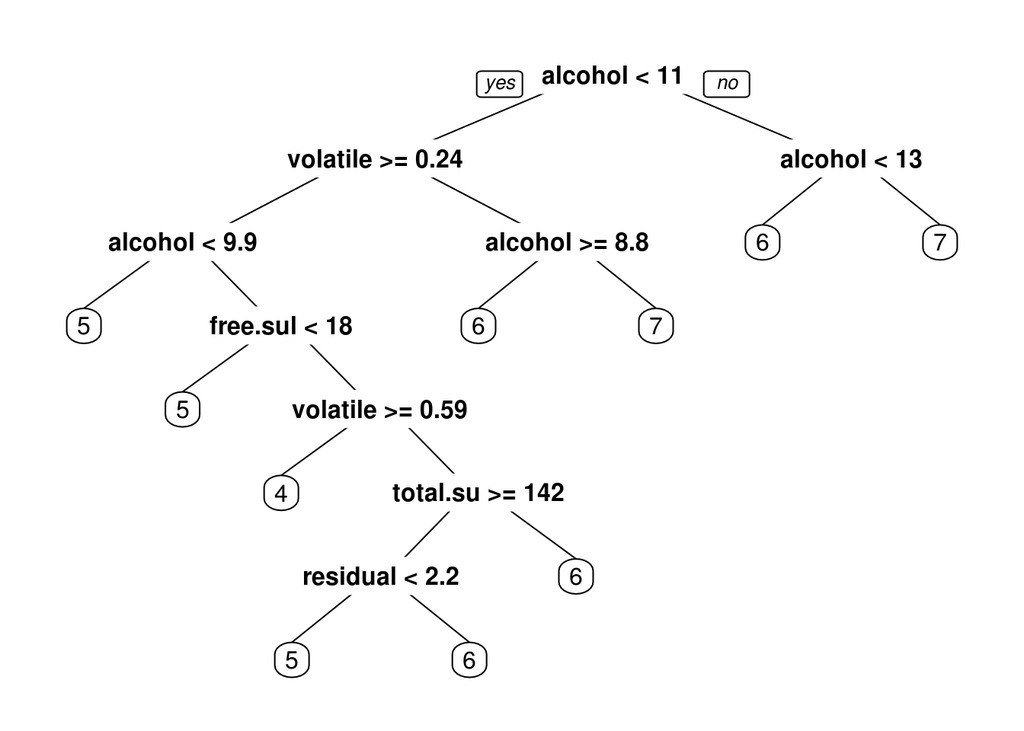

```r
library(rpart)
library(rpart.plot)
library(caret)
library(e1071)

whiteWines$quality = factor(whiteWines$quality)

# Split data into a train and test set
index <- 1:nrow(whiteWines)
set.seed(144)
wtestSamples <- sample(index, trunc(length(index)/3))
wqindex <- which(colnames(whiteWines)=="quality")
wqlindex <- which(colnames(whiteWines)=="quality.label")
whiteTest <- whiteWines[wtestSamples,-wqlindex]
whiteTrain <- whiteWines[-wtestSamples,-wqlindex]

# Create rpart model with cross validation
wtr.control = trainControl(method = "cv", number = 5)
wcp.grid = expand.grid( .cp = (0:4)*0.001)
set.seed(144)
wrpart.grid = train(data = whiteTrain, quality ~ . - citric.acid - density
    - pH , method = "rpart", trControl = wtr.control, tuneGrid = cp.grid)


wrpart.model = wrpart.grid$finalModel
prp(wrpart.model)
```

```r
#Compute confusion matrix
wrpart.cpred <- predict(wrpart.model, whiteTest, type = "class" )
wrpart.cmatrix <- table(pred = wrpart.cpred, true = whiteTest[,wqindex])
wrpart.accuracy <- sum(diag(wrpart.cmatrix))/sum(wrpart.cmatrix)
wrpart.cmatrix
```

```
##     true
## pred   3   4   5   6   7   8   9
##    3   0   0   0   0   0   0   0
##    4   0   0   1   1   0   0   0
##    5   2  34 272 154  15   0   0
##    6   5  25 199 542 245  49   0
##    7   1   2   5  27  44   9   0
##    8   0   0   0   0   0   0   0
##    9   0   0   0   0   0   0   0
```

```r
wrpart.accuracy
```

```
## [1] 0.5257353
```

[output not shown]

### Final Plots and Summary

This report explored the relationship betwen chemical properties of red and white wines, and their quality as identified by wine experts. Several plots including histograms, density plots, box plots, and scatter plots were used in the exploration to identify three major featurs impacting wine quality. They are alcohol content, fixed acidity, and volatile acidity.

This section reproduces a few of those plots. For example, the density plots of red wine quality over the three features are shown below. Detailed code for generating these plots have already been included in earlier sections.

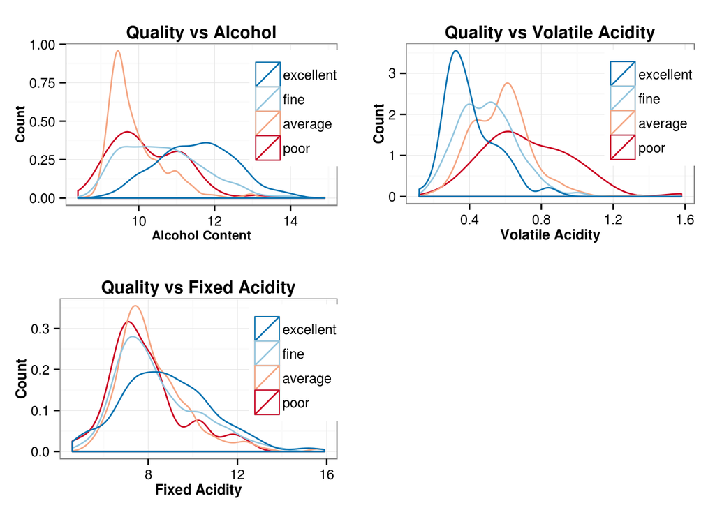

```r
grid.arrange(alDensity, vaDensity, faDensity, nrow=2, ncol=2)
```

For white wines, the relationsip between quality, alcohol content and volatile acidity can be seen in the following scatter plot.

```r
alvascatter
```

[figure not shown]

We also built regression and classification models to predict wine quality from its chemical properties. The classification trees identified two additional significant features, namely residual sugar and sulphates. In the following we show the classification-tree for white wines. Detailed code for generating the model have already been included in an earlier section.

```r
prp(wrpart.model)
```

[figure not shown]

### Reflection

In this report, we have explored the relationship betwen chemical properties of wines, such as fixed and volatile acidity, residual sugar, sulphates, alcohol content, and the quality of the wines as identified by the experts. We started with 11 different independent input variables, and showed that one can pick fine or excellent wines by focusing on 5 or fewer primary contributors. However, our prdictive models are not accurate enough (58% for red and 52 % for white). Despite providing interesting insights, they need to more refined before providing reliable wine ratings. In addition to linear regression and CART models used in this project, there exists other advanced techniques for extracting features and building and training models that can be used to create a better predictive model for wine quality.